# Introduction

CRISP-DM process contains following stages:

1. Business Understanding
2. Data Understanding
3. Data Preparation
4. Modeling
5. Evaluation
6. Deploy

I shall use all these stages except deployment, to demonstrate using CRISP-DM in order to explore and find out answers for my questions.  
Credit for the data goes to Stackoverflow survey (https://insights.stackoverflow.com/survey/). I shall use data from 2017, 2018 and 2019 surveys for my analysis.

# 1. Business Understanding

I am one of such people who has spent a decade and a half in software industry. Being in one of the most dynamic industries in the world, I have witnessed few rises and falls, worked in quite a few of technologies. As usual, at times, I ponder over my profile and its relevance to the industry. I do believe that many professionals, as I do, want to remain relevant by picking up new skills.  
Therefore, first thing I would like to know is what's the trend in the industry.  
I like programming and am working in India. Therefore, I would also like to know popular languages in India.  
Finally, we can't ignore financial aspects of our profession. Therefore, it would be fitting if I can find out how people are earning by using these programming languages.  
Specifically, I would like to know the answers to following questions:

1. What are the most common programming languages, databases, platforms, technologies and tools used across the world in 2019?
2. What are the most popular programming languages in India?
3. What is the salary earned on average for each programming language?

# 2. Data Understanding

Every year, Stackoverflow conducts a survey covering all sorts of information like programming languages, jobs, salaries, job-satisfaction etc. All of these data can be found in https://insights.stackoverflow.com/survey/. I am going to use the data collected as part of 2017, 2018 and 2019 surveys, in order to find answers to my questions.

```python
import numpy as np
import pandas as pd
from collections import Counter
import matplotlib.pyplot as plt
%matplotlib inline
import seaborn as sns
import warnings

# to change plot style
sns.set(style="darkgrid")

# to ignore warnings
warnings.filterwarnings("ignore")
```

## Stackoverflow data

In order to understand the data and use it in line with my business understanding, I shall load the data and inspect various aspects.

```python
# read 2019 survey data
df_2019 = pd.read_csv('./survey_results_public_2019.csv')
df_2019.head()
```

|  | Respondent | MainBranch | Hobbyist | OpenSourcer | OpenSource | Employment | Country | Student | EdLevel | UndergradMajor | ... | WelcomeChange | SONewContent | Age | Gender | Trans | Sexuality | Ethnicity | Dependents | SurveyLength | SurveyEase |
| --- | --- | --- | --- | --- | --- | --- | --- | --- | --- | --- | --- | --- | --- | --- | --- | --- | --- | --- | --- | --- | --- |
| 0 | 1 | I am a student who is learning to code | Yes | Never | The quality of OSS and closed source software ... | Not employed, and not looking for work | United Kingdom | No | Primary/elementary school | NaN | ... | Just as welcome now as I felt last year | Tech articles written by other developers;Indu... | 14.0 | Man | No | Straight / Heterosexual | NaN | No | Appropriate in length | Neither easy nor difficult |
| 1 | 2 | I am a student who is learning to code | No | Less than once per year | The quality of OSS and closed source software ... | Not employed, but looking for work | Bosnia and Herzegovina | Yes, full-time | Secondary school (e.g. American high school, G... | NaN | ... | Just as welcome now as I felt last year | Tech articles written by other developers;Indu... | 19.0 | Man | No | Straight / Heterosexual | NaN | No | Appropriate in length | Neither easy nor difficult |
| 2 | 3 | I am not primarily a developer, but I write co... | Yes | Never | The quality of OSS and closed source software ... | Employed full-time | Thailand | No | Bachelor’s degree (BA, BS, B.Eng., etc.) | Web development or web design | ... | Just as welcome now as I felt last year | Tech meetups or events in your area;Courses on... | 28.0 | Man | No | Straight / Heterosexual | NaN | Yes | Appropriate in length | Neither easy nor difficult |
| 3 | 4 | I am a developer by profession | No | Never | The quality of OSS and closed source software ... | Employed full-time | United States | No | Bachelor’s degree (BA, BS, B.Eng., etc.) | Computer science, computer engineering, or sof... | ... | Just as welcome now as I felt last year | Tech articles written by other developers;Indu... | 22.0 | Man | No | Straight / Heterosexual | White or of European descent | No | Appropriate in length | Easy |
| 4 | 5 | I am a developer by profession | Yes | Once a month or more often | OSS is, on average, of HIGHER quality than pro... | Employed full-time | Ukraine | No | Bachelor’s degree (BA, BS, B.Eng., etc.) | Computer science, computer engineering, or sof... | ... | Just as welcome now as I felt last year | Tech meetups or events in your area;Courses on... | 30.0 | Man | No | Straight / Heterosexual | White or of European descent;Multiracial | No | Appropriate in length | Easy |

5 rows × 85 columns

```python
# read 2018 survey data
df_2018 = pd.read_csv('./survey_results_public_2018.csv')
df_2018.head()
```

|  | Respondent | Hobby | OpenSource | Country | Student | Employment | FormalEducation | UndergradMajor | CompanySize | DevType | ... | Exercise | Gender | SexualOrientation | EducationParents | RaceEthnicity | Age | Dependents | MilitaryUS | SurveyTooLong | SurveyEasy |
| --- | --- | --- | --- | --- | --- | --- | --- | --- | --- | --- | --- | --- | --- | --- | --- | --- | --- | --- | --- | --- | --- |
| 0 | 1 | Yes | No | Kenya | No | Employed part-time | Bachelor’s degree (BA, BS, B.Eng., etc.) | Mathematics or statistics | 20 to 99 employees | Full-stack developer | ... | 3 - 4 times per week | Male | Straight or heterosexual | Bachelor’s degree (BA, BS, B.Eng., etc.) | Black or of African descent | 25 - 34 years old | Yes | NaN | The survey was an appropriate length | Very easy |
| 1 | 3 | Yes | Yes | United Kingdom | No | Employed full-time | Bachelor’s degree (BA, BS, B.Eng., etc.) | A natural science (ex. biology, chemistry, phy... | 10,000 or more employees | Database administrator;DevOps specialist;Full-... | ... | Daily or almost every day | Male | Straight or heterosexual | Bachelor’s degree (BA, BS, B.Eng., etc.) | White or of European descent | 35 - 44 years old | Yes | NaN | The survey was an appropriate length | Somewhat easy |
| 2 | 4 | Yes | Yes | United States | No | Employed full-time | Associate degree | Computer science, computer engineering, or sof... | 20 to 99 employees | Engineering manager;Full-stack developer | ... | NaN | NaN | NaN | NaN | NaN | NaN | NaN | NaN | NaN | NaN |
| 3 | 5 | No | No | United States | No | Employed full-time | Bachelor’s degree (BA, BS, B.Eng., etc.) | Computer science, computer engineering, or sof... | 100 to 499 employees | Full-stack developer | ... | I don't typically exercise | Male | Straight or heterosexual | Some college/university study without earning ... | White or of European descent | 35 - 44 years old | No | No | The survey was an appropriate length | Somewhat easy |
| 4 | 7 | Yes | No | South Africa | Yes, part-time | Employed full-time | Some college/university study without earning ... | Computer science, computer engineering, or sof... | 10,000 or more employees | Data or business analyst;Desktop or enterprise... | ... | 3 - 4 times per week | Male | Straight or heterosexual | Some college/university study without earning ... | White or of European descent | 18 - 24 years old | Yes | NaN | The survey was an appropriate length | Somewhat easy |

5 rows × 129 columns

```python
# read 2017 survey data
df_2017 = pd.read_csv('./survey_results_public_2017.csv')
df_2017.head()
```

|  | Respondent | Professional | ProgramHobby | Country | University | EmploymentStatus | FormalEducation | MajorUndergrad | HomeRemote | CompanySize | ... | StackOverflowMakeMoney | Gender | HighestEducationParents | Race | SurveyLong | QuestionsInteresting | QuestionsConfusing | InterestedAnswers | Salary | ExpectedSalary |
| --- | --- | --- | --- | --- | --- | --- | --- | --- | --- | --- | --- | --- | --- | --- | --- | --- | --- | --- | --- | --- | --- |
| 0 | 1 | Student | Yes, both | United States | No | Not employed, and not looking for work | Secondary school | NaN | NaN | NaN | ... | Strongly disagree | Male | High school | White or of European descent | Strongly disagree | Strongly agree | Disagree | Strongly agree | NaN | NaN |
| 1 | 2 | Student | Yes, both | United Kingdom | Yes, full-time | Employed part-time | Some college/university study without earning ... | Computer science or software engineering | More than half, but not all, the time | 20 to 99 employees | ... | Strongly disagree | Male | A master's degree | White or of European descent | Somewhat agree | Somewhat agree | Disagree | Strongly agree | NaN | 37500.0 |
| 2 | 3 | Professional developer | Yes, both | United Kingdom | No | Employed full-time | Bachelor's degree | Computer science or software engineering | Less than half the time, but at least one day ... | 10,000 or more employees | ... | Disagree | Male | A professional degree | White or of European descent | Somewhat agree | Agree | Disagree | Agree | 113750.0 | NaN |
| 3 | 4 | Professional non-developer who sometimes write... | Yes, both | United States | No | Employed full-time | Doctoral degree | A non-computer-focused engineering discipline | Less than half the time, but at least one day ... | 10,000 or more employees | ... | Disagree | Male | A doctoral degree | White or of European descent | Agree | Agree | Somewhat agree | Strongly agree | NaN | NaN |
| 4 | 5 | Professional developer | Yes, I program as a hobby | Switzerland | No | Employed full-time | Master's degree | Computer science or software engineering | Never | 10 to 19 employees | ... | NaN | NaN | NaN | NaN | NaN | NaN | NaN | NaN | NaN | NaN |

5 rows × 154 columns

## Schema of stackoverflow survey data

Understanding the schema will help to understand the dataset. Let's load the schema and see the definitions.

```python
# read 2019 schema
schema_2019 = pd.read_csv('./survey_results_schema_2019.csv')
schema_2019.head()
```

|  | Column | QuestionText |
| --- | --- | --- |
| 0 | Respondent | Randomized respondent ID number (not in order ... |
| 1 | MainBranch | Which of the following options best describes ... |
| 2 | Hobbyist | Do you code as a hobby? |
| 3 | OpenSourcer | How often do you contribute to open source? |
| 4 | OpenSource | How do you feel about the quality of open sour... |

```python
# read 2018 schema
schema_2018 = pd.read_csv('./survey_results_schema_2018.csv')
schema_2018.head()
```

|  | Column | QuestionText |
| --- | --- | --- |
| 0 | Respondent | Randomized respondent ID number (not in order ... |
| 1 | Hobby | Do you code as a hobby? |
| 2 | OpenSource | Do you contribute to open source projects? |
| 3 | Country | In which country do you currently reside? |
| 4 | Student | Are you currently enrolled in a formal, degree... |

```python
# read 2017 schema
schema_2017 = pd.read_csv('./survey_results_schema_2017.csv')
schema_2017.head()
```

|  | Column | Question |
| --- | --- | --- |
| 0 | Respondent | Respondent ID number |
| 1 | Professional | Which of the following best describes you? |
| 2 | ProgramHobby | Do you program as a hobby or contribute to ope... |
| 3 | Country | In which country do you currently live? |
| 4 | University | Are you currently enrolled in a formal, degree... |

# Question 1 - What are the most common programming languages, databases, platforms, frameworks and tools used across the world in 2019?

## 1.3. Data preparation

In order to find answer to question 1, I shall use only the data from 2019 survey. I need most recent trend, and hence, I won't use 2018 or 2017 data here. According to 2019 schema, following columns are important:

1. LanguageWorkedWith
2. DatabaseWorkedWith
3. PlatformWorkedWith
4. WebFrameWorkedWith
5. DevEnviron

I am going to include all respondents, irrespective of their profession, age or nationality. Accordingly, a dataset containing only above-mentioned columns can be used for relevant analysis.

```python
q1_df = df_2019[['LanguageWorkedWith','DatabaseWorkedWith','PlatformWorkedWith','WebFrameWorkedWith','DevEnviron']]
q1_df.head()
```

|  | LanguageWorkedWith | DatabaseWorkedWith | PlatformWorkedWith | WebFrameWorkedWith | DevEnviron |
| --- | --- | --- | --- | --- | --- |
| 0 | HTML/CSS;Java;JavaScript;Python | SQLite | MacOS;Windows | Django;Flask | IntelliJ;Notepad++;PyCharm |
| 1 | C++;HTML/CSS;Python | NaN | Windows | Django | Atom;PyCharm |
| 2 | HTML/CSS | PostgreSQL | NaN | NaN | Vim;Visual Studio Code |
| 3 | C;C++;C#;Python;SQL | MySQL;SQLite | Linux;Windows | NaN | Eclipse;Vim;Visual Studio;Visual Studio Code |
| 4 | C++;HTML/CSS;Java;JavaScript;Python;SQL;VBA | Couchbase;MongoDB;MySQL;Oracle;PostgreSQL;SQLite | Android;Linux;MacOS;Slack;Windows | Django;Express;Flask;jQuery;React.js;Spring | IntelliJ;Notepad++;Vim |

## 1.4. Modelling

As I can see here, many columns contain multiple responses, delimited by semicolon (;). Accordingly, response will be splitted to find meaningful information. However, in few cases, there is no response.

```python
def check_quality(df, col_name):
    no_response_percent = (df[col_name].isnull().sum() / df.shape[0]) * 100
    print('Percentage of missing responses on {}: {:.2f}%'.format(col_name, no_response_percent))
```

```python
def plot(df, col_name, plot_name):
    languages = df[col_name].str.split(';', expand=True).stack().value_counts()
    plt.figure(figsize=(10,10))
    languages.plot(kind="bar")

    plt.savefig(plot_name)
```

### 1.4.1 Most common programming languages

```python
# checking quality of data received
language_col = 'LanguageWorkedWith'
check_quality(q1_df, language_col)
```

```
Percentage of missing responses on LanguageWorkedWith: 1.48%
```

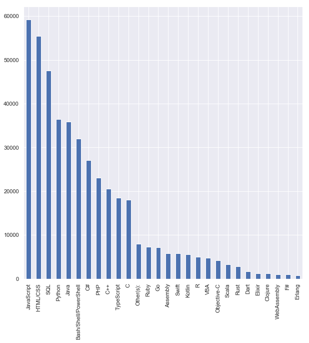

```python
plot(q1_df, language_col, 'languages')
```

### 1.4.2 Most common databases

```python
# checking quality of data received
db_col = 'DatabaseWorkedWith'
check_quality(q1_df, db_col)
```

```
Percentage of missing responses on DatabaseWorkedWith: 14.47%
```

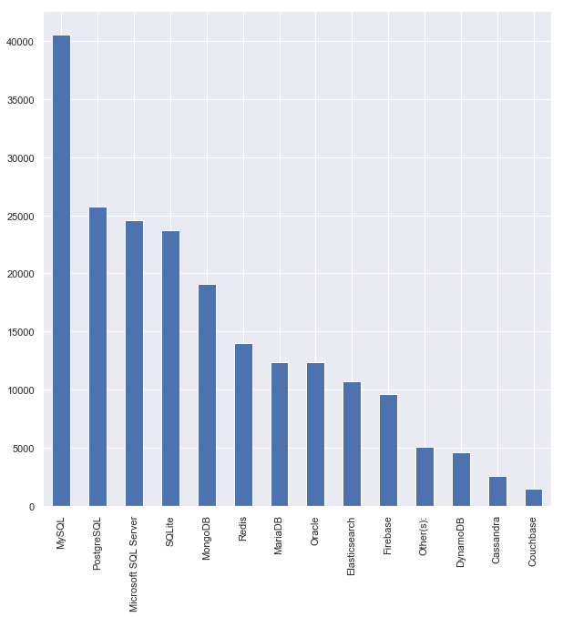

```python
plot(q1_df, db_col, 'databases')
```

### 1.4.3 Most common platforms

```python
platform_col = 'PlatformWorkedWith'
# check quality
check_quality(q1_df, platform_col)
```

```
Percentage of missing responses on PlatformWorkedWith: 9.19%
```

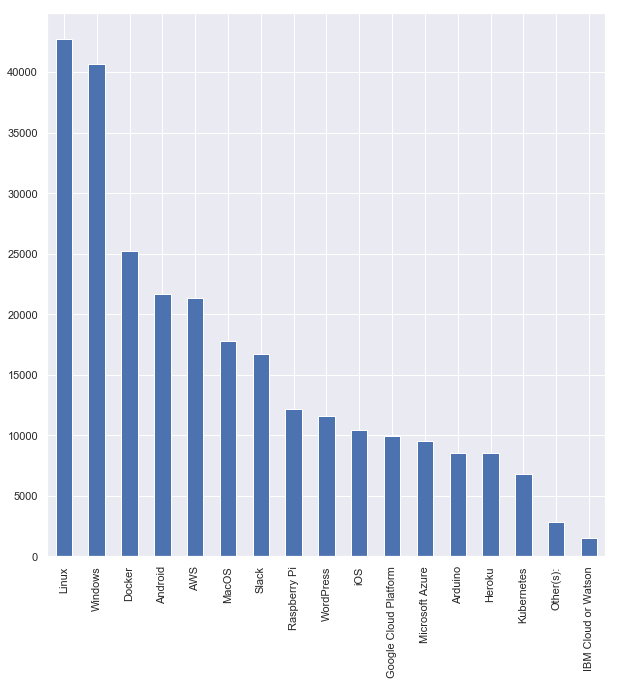

```python
plot(q1_df, platform_col, 'platforms')
```

### 1.4.4 Most common frameworks

```python
web_framework_col = 'WebFrameWorkedWith'
# check quality
check_quality(q1_df, web_framework_col)
```

```
Percentage of missing responses on WebFrameWorkedWith: 26.85%
```

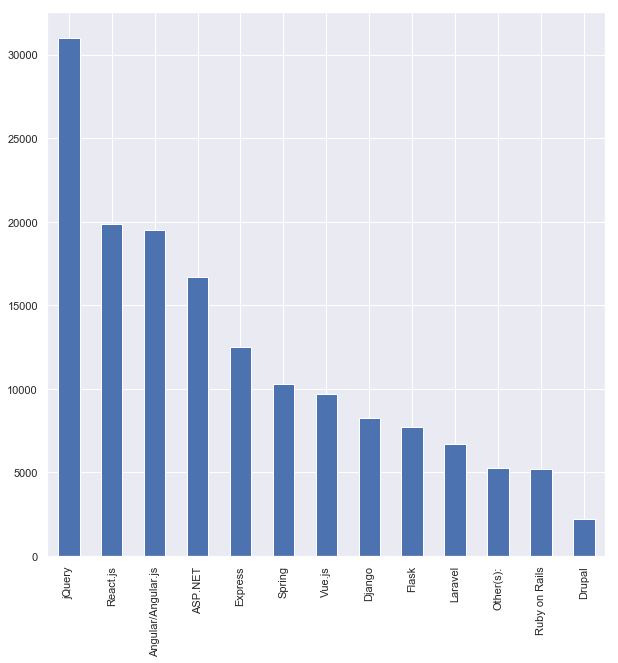

```python
plot(q1_df, web_framework_col, 'web_frameworks')
```

### 1.4.5 Most common tools for development

```python
dev_env_col = 'DevEnviron'
# check quality
check_quality(q1_df, dev_env_col)
```

```
Percentage of missing responses on DevEnviron: 1.76%
```

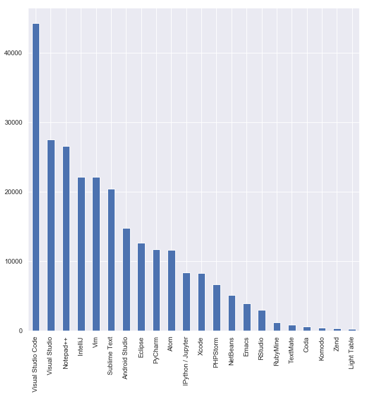

```python
plot(q1_df, dev_env_col, 'dev_envs')
```

## 1.5 Evaluation

- Top 5 most common programming languages and scripts: JavaScript, HTML/CSS, SQL, Python, Java
- Top 5 most common databases: MySql, PostgreSql, Microsoft SQL Server, SQLite, MongoDB
- Top 5 most common platforms: Linux, Windows, Docker, Android, AWS
- Top 5 most common frameworks: jQuery, React.js, Angular.js, ASP.NET, Express
- Top 5 most common development tools: Visual Studio Code, Visual Studio, Notepad++, IntelliJ, Vim

# Question 2 - What are the most popular programming languages in India?

## 2.3. Data preparation

Answer to this question 2 has two aspects. People might be using some languages and have fallen in love with those. Also, there may be cases where people aspire to learn some new languages but haven't worked on them so far. So, I have to consider both of these aspects. Thankfully, the survey data from Stackoverflow captures both responses.  
Moreover, in order to find answer to this question, I shall check data for last 3 years. That should show a historical trend for last 3 years, in Indian software industry. Therefore, I need to check data from 2017, 2018 and 2019 surveys.  
As it is already evident, my analysis will be limited to the data related to India only.  
I am going to include all respondents, irrespective of their profession, age or nationality.  
According to **2019** schema, following columns will be required:

```
- Country
- LanguageWorkedWith
- LanguageDesireNextYear
```

According to **2018** schema, following columns will be required:

```
- Country
- LanguageWorkedWith
- LanguageDesireNextYear
```

According to **2017** schema, following columns will be required:

```
- Country
- HaveWorkedLanguage
- WantWorkLanguage
```

```python
q2_df_2019 = df_2019[['Country','LanguageWorkedWith','LanguageDesireNextYear']]
q2_df_2019 = q2_df_2019[q2_df_2019['Country']=='India']
q2_df_2019.head()
```

|  | Country | LanguageWorkedWith | LanguageDesireNextYear |
| --- | --- | --- | --- |
| 7 | India | Bash/Shell/PowerShell;C;C++;HTML/CSS;Java;Java... | Bash/Shell/PowerShell;C;C++;Elixir;Erlang;Go;P... |
| 9 | India | C#;Go;JavaScript;Python;R;SQL | C#;Go;JavaScript;Kotlin;Python;R;SQL |
| 14 | India | Assembly;Bash/Shell/PowerShell;C;C++;HTML/CSS;... | Assembly;Bash/Shell/PowerShell;C;C++;C#;Go;HTM... |
| 49 | India | Bash/Shell/PowerShell;C;C++;HTML/CSS;Java;Java... | HTML/CSS;JavaScript;Python |
| 64 | India | Assembly;C;C++;C#;HTML/CSS;Java | Kotlin |

```python
q2_df_2018 = df_2018[['Country','LanguageWorkedWith','LanguageDesireNextYear']]
q2_df_2018 = q2_df_2018[q2_df_2018['Country']=='India']
q2_df_2018.head()
```

|  | Country | LanguageWorkedWith | LanguageDesireNextYear |
| --- | --- | --- | --- |
| 9 | India | NaN | NaN |
| 11 | India | NaN | NaN |
| 13 | India | Java | Java;Python |
| 18 | India | C;C++;C# | Python;R |
| 24 | India | C;C++;Java;JavaScript;SQL;Swift;Kotlin | Java;JavaScript;Swift;Kotlin |

```python
q2_df_2017 = df_2017[['Country','HaveWorkedLanguage','WantWorkLanguage']]
q2_df_2017 = q2_df_2017[q2_df_2017['Country']=='India']
q2_df_2017.head()
```

|  | Country | HaveWorkedLanguage | WantWorkLanguage |
| --- | --- | --- | --- |
| 26 | India | Java; JavaScript; Objective-C; Python; Swift | Go; Java; JavaScript; R; Swift |
| 61 | India | C#; JavaScript; SQL | Java; Objective-C |
| 66 | India | C++; C#; Objective-C | C++; C#; Python |
| 94 | India | C; C#; SQL | JavaScript; R |
| 107 | India | C; Python | C#; Common Lisp; R; Rust; SQL |

## 2.4. Modelling

As I can see here, language columns contain multiple responses, delimited by semicolon (;). Accordingly, response will be splitted to find meaningful information. However, in few cases, there is no response.

```python
def split_multivalued_column(df, col):
    # drop all null values
    df_copy = df.dropna(axis=0, how='any')

    #Split column by ;
    df_copy = df_copy[col].apply(lambda x: x.split(';'))

    return df_copy
```

```python
def process_data(df, col, year):
    column_series = split_multivalued_column(df, col)

    data_list = []
    for row in column_series:
        for obj in row:
            data_list.append(obj.strip())

    #Group by count to a list
    grouped_list = dict(Counter(data_list))
    grouped_dict = [{'Programming Language':key, 'Count': value, 'Year': year} for key, value in grouped_list.items()]

    return pd.DataFrame(grouped_dict)
```

```python
india_worked_lang_2019 = process_data(q2_df_2019, 'LanguageWorkedWith', '2019')
india_wanted_lang_2019 = process_data(q2_df_2019, 'LanguageDesireNextYear', '2019')
india_worked_lang_2018 = process_data(q2_df_2018, 'LanguageWorkedWith', '2018')
india_wanted_lang_2018 = process_data(q2_df_2018, 'LanguageDesireNextYear', '2018')
india_worked_lang_2017 = process_data(q2_df_2017, 'HaveWorkedLanguage', '2017')
india_wanted_lang_2017 = process_data(q2_df_2017, 'WantWorkLanguage', '2017')
```

```python
# append the dataframes
india_worked_lang = india_worked_lang_2019.append(india_worked_lang_2018).append(india_worked_lang_2017)
india_wanted_lang = india_wanted_lang_2019.append(india_wanted_lang_2018).append(india_wanted_lang_2017)
```

```python
def compute_percent(df, column):
    df_copy = df
    series = []

    for val in df_copy[column].unique():
        series.append(df_copy[df_copy[column] == val]['Count'] /
                      df_copy[df_copy[column] == val]['Count'].sum())

    combined_series = pd.Series()
    for series_elem in series:
        combined_series = combined_series.append(series_elem)

    return combined_series
```

```python
# Computing the percentage
india_worked_lang['Percentage'] = compute_percent(india_worked_lang, 'Year')
india_wanted_lang['Percentage'] = compute_percent(india_wanted_lang, 'Year')
```

```python
# Get top languages
count = 10
india_top_worked_lang = india_worked_lang.sort_values(by=['Percentage'], ascending=False).head(count)['Programming Language'].unique()
india_top_wanted_lang = india_wanted_lang.sort_values(by=['Percentage'], ascending=False).head(count)['Programming Language'].unique()

worked_lang_chart = india_worked_lang[india_worked_lang['Programming Language'].isin(india_top_worked_lang)]
wanted_lang_chart = india_wanted_lang[india_wanted_lang['Programming Language'].isin(india_top_wanted_lang)]
```

```python
def plot_comparison_chart(df, heading):
    plt.figure(figsize=(14,8))
    sns.barplot(x = 'Percentage',
            y = 'Programming Language',
            hue = 'Year',
            data = df.sort_values(by='Percentage', ascending=False))

    plt.xlabel("Percentage", fontsize = 14)
    plt.ylabel("Programming Languages", fontsize = 14)
    plt.legend(fontsize='x-large', title_fontsize='40')
    plt.title(heading, size = 16)
    plt.show()
```

### 2.4.1 Most popular languages as used in India

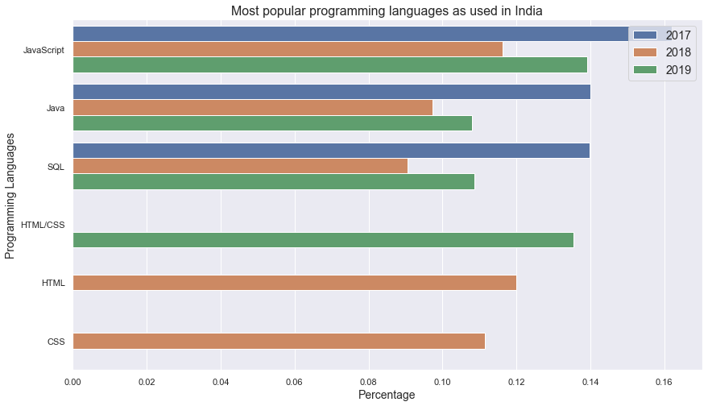

```python
plot_comparison_chart(worked_lang_chart, 'Most popular programming languages as used in India')
```

### 2.4.2 Most popular languages as desired in India

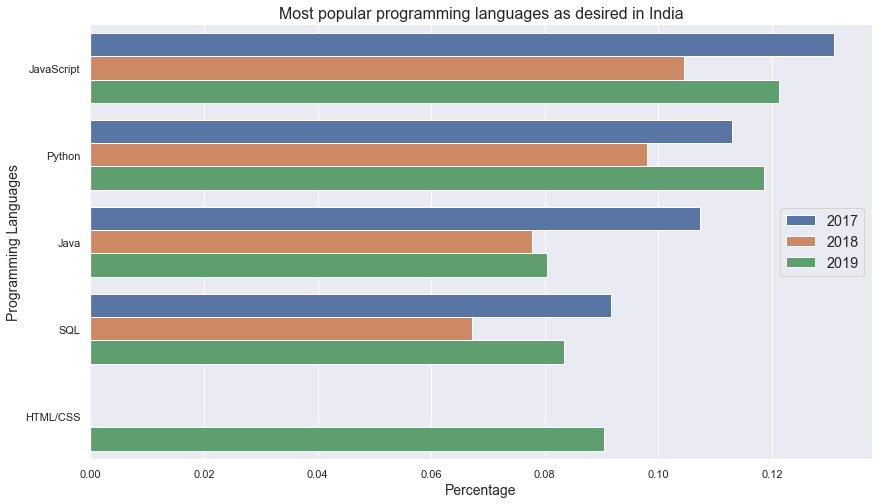

```python
plot_comparison_chart(wanted_lang_chart, 'Most popular programming languages as desired in India')
```

### 2.4.3 How do languages used in work relate to languages desired to be learnt

```python
def create_matrix(worked_lang, wanted_lang):
    # group data together
    rows = []
    for itens in list(zip(worked_lang, wanted_lang)):
        for i in itens[0]:
            rows.append({
                'Worked_PL': i,
                'Wanted_PL': Counter(itens[0])
            })
    combined_lang_df = pd.DataFrame(rows).groupby('Worked_PL').agg({'Wanted_PL': 'sum'}).reset_index()

    # start forming the matrix
    for row in combined_lang_df['Worked_PL']:
        combined_lang_df[row] = 0

    for index, row in combined_lang_df.iterrows():
        total = sum([value for key, value in dict(row['Wanted_PL']).items()])
        for key, value in dict(row['Wanted_PL']).items():
            combined_lang_df[key].loc[index] = (value / total)

    matrix = combined_lang_df.drop('Wanted_PL', axis=1).set_index('Worked_PL')

    return matrix
```

```python
def plot_correlation_heatmap(matrix, heading):
    plt.figure(figsize=(16, 10))
    sns.heatmap(matrix, cmap="YlGnBu")
    plt.title(heading, size = 16)
    plt.ylabel('')
    plt.show()
```

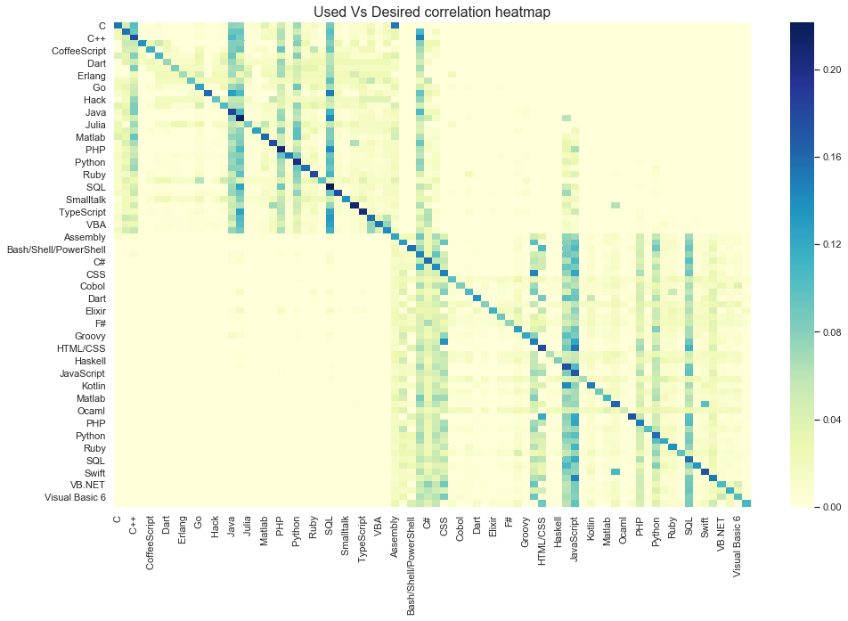

```python
ind_worked_lang_2019 = split_multivalued_column(q2_df_2019, 'LanguageWorkedWith')
ind_worked_lang_2018 = split_multivalued_column(q2_df_2018, 'LanguageWorkedWith')
ind_worked_lang_2017 = split_multivalued_column(q2_df_2017, 'HaveWorkedLanguage')
ind_worked_lang = ind_worked_lang_2019.append(ind_worked_lang_2018).append(ind_worked_lang_2017)

ind_desired_lang_2019 = split_multivalued_column(q2_df_2019, 'LanguageDesireNextYear')
ind_desired_lang_2018 = split_multivalued_column(q2_df_2018, 'LanguageDesireNextYear')
ind_desired_lang_2017 = split_multivalued_column(q2_df_2017, 'WantWorkLanguage')
ind_desired_lang = ind_desired_lang_2019.append(ind_desired_lang_2018).append(ind_desired_lang_2017)

matrix = create_matrix(ind_worked_lang, ind_desired_lang)
plot_correlation_heatmap(matrix, 'Used Vs Desired correlation heatmap')
```

# Question 3 - What is the salary earned on average for each programming language?

## 3.3. Data preparation

I shall do this analysis across the world. Therefore, I shall pick data based on following criteria:

- annual salary
- languages worked upon

Interesting point to note here is that I am not filtering my data, based on profession. That's because, I want to include all sorts of employment, for example, full-time salaried, part-time contractor, freelancer etc.

According to **2017** schema, following columns will be required:

```
- 'HaveWorkedLanguage' column
- 'Salary' column
```

According to **2018** schema, following columns will be required:

```
- 'LanguageWorkedWith' column
- 'ConvertedSalary' column
```

According to **2019** schema, following columns will be required:

```
- 'LanguageWorkedWith' column
- 'ConvertedComp' column
```

```python
q3_df_2017 = df_2017[['HaveWorkedLanguage','Salary']]
# drop all rows which don't have data
q3_df_2017 = q3_df_2017.dropna(axis=0, how='any')
q3_df_2017.head()
```

|  | HaveWorkedLanguage | Salary |
| --- | --- | --- |
| 2 | Java; PHP; Python | 113750.0 |
| 14 | Assembly; C; C++ | 100000.0 |
| 17 | C; Clojure; JavaScript; Matlab; Rust; SQL; Swift | 130000.0 |
| 22 | Java | 100764.0 |
| 25 | Java; Scala | 175000.0 |

```python
q3_df_2018 = df_2018[['LanguageWorkedWith','ConvertedSalary']]
# drop all rows which don't have data
q3_df_2018 = q3_df_2018.dropna(axis=0, how='any')
q3_df_2018.head()
```

|  | LanguageWorkedWith | ConvertedSalary |
| --- | --- | --- |
| 1 | JavaScript;Python;Bash/Shell | 70841.0 |
| 4 | C;C++;Java;Matlab;R;SQL;Bash/Shell | 21426.0 |
| 5 | Java;JavaScript;Python;TypeScript;HTML;CSS | 41671.0 |
| 6 | JavaScript;HTML;CSS | 120000.0 |
| 8 | Assembly;CoffeeScript;Erlang;Go;JavaScript;Lua... | 250000.0 |

```python
q3_df_2019 = df_2019[['LanguageWorkedWith','ConvertedComp']]
# drop all rows which don't have data
q3_df_2019 = q3_df_2019.dropna(axis=0, how='any')
q3_df_2019.head()
```

|  | LanguageWorkedWith | ConvertedComp |
| --- | --- | --- |
| 2 | HTML/CSS | 8820.0 |
| 3 | C;C++;C#;Python;SQL | 61000.0 |
| 5 | Java;R;SQL | 366420.0 |
| 8 | Bash/Shell/PowerShell;C#;HTML/CSS;JavaScript;P... | 95179.0 |
| 9 | C#;Go;JavaScript;Python;R;SQL | 13293.0 |

## 3.4. Modelling

```python
def split_col(df, col_to_split, delimeter, col_to_retain):
    df_out = pd.DataFrame(columns = [col_to_split, col_to_retain])
    for index, row in df.iterrows():
        columns = row[col_to_split].split(delimeter)
        for c in columns:
            df_out.loc[len(df_out)] = [c, row[col_to_retain]]

    return df_out
```

```python
q3_2017 = split_col(q3_df_2017, 'HaveWorkedLanguage', ';', 'Salary')
q3_2017.head()
```

|  | HaveWorkedLanguage | Salary |
| --- | --- | --- |
| 0 | Java | 113750.0 |
| 1 | PHP | 113750.0 |
| 2 | Python | 113750.0 |
| 3 | Assembly | 100000.0 |
| 4 | C | 100000.0 |

```python
q3_2018 = split_col(q3_df_2018, 'LanguageWorkedWith', ';', 'ConvertedSalary')
q3_2018.head()
```

|  | LanguageWorkedWith | ConvertedSalary |
| --- | --- | --- |
| 0 | JavaScript | 70841.0 |
| 1 | Python | 70841.0 |
| 2 | Bash/Shell | 70841.0 |
| 3 | C | 21426.0 |
| 4 | C++ | 21426.0 |

```python
q3_2019 = split_col(q3_df_2019, 'LanguageWorkedWith', ';', 'ConvertedComp')
q3_2019.head()
```

|  | LanguageWorkedWith | ConvertedComp |
| --- | --- | --- |
| 0 | HTML/CSS | 8820.0 |
| 1 | C | 61000.0 |
| 2 | C++ | 61000.0 |
| 3 | C# | 61000.0 |
| 4 | Python | 61000.0 |

```python
# align each dataset with common column-names and merge 3 years of data
q3_2017.rename(columns = {'HaveWorkedLanguage':'language'}, inplace = True)
q3_2018.rename(columns = {'LanguageWorkedWith':'language', 'ConvertedSalary':'Salary'}, inplace = True)
q3_2019.rename(columns = {'LanguageWorkedWith':'language', 'ConvertedComp':'Salary'}, inplace = True)

q3_df = q3_2019.append(q3_2018).append(q3_2017)
q3_df.head()
```

|  | language | Salary |
| --- | --- | --- |
| 0 | HTML/CSS | 8820.0 |
| 1 | C | 61000.0 |
| 2 | C++ | 61000.0 |
| 3 | C# | 61000.0 |
| 4 | Python | 61000.0 |

```python
q3_ans_df = q3_df
q3_ans_df['language'] = q3_ans_df['language'].apply(lambda x: x.strip())
```

```python
def plot_mean_data(df, group_by_col, col_to_show, plot_name):
    group_by_values = df[group_by_col].unique()
    grp = df.groupby(group_by_col)
    mean_values = []
    for group_by_value in group_by_values:
        mean_value = grp.get_group(group_by_value)[col_to_show].mean()
        mean_values.append(mean_value)

    list_of_tuples = list(zip(group_by_values, mean_values))
    df_for_plot = pd.DataFrame(list_of_tuples, columns = [group_by_col, col_to_show]).sort_values(col_to_show)
    plt.rcParams["figure.figsize"] = [16,9]
    df_for_plot.plot.bar(x=group_by_col, y=col_to_show)
    plt.savefig(plot_name)
```

### Average salary Vs language plot

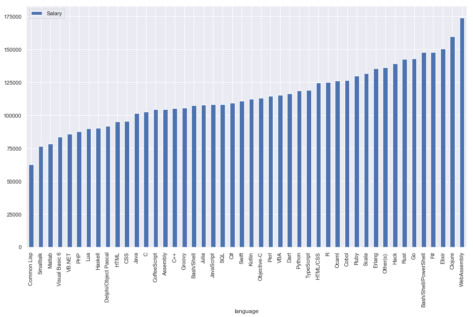

```python
plot_mean_data(q3_ans_df, 'language', 'Salary', 'Salary_vs_Language_plot')
```

## 3.5. Evaluation

This graph shows some interesting results. None of the most commonly used or desired languages is among the top 5 earners. In fact, more than 50% of languages have higher average salary than JavaScript. Rank of Java is much lower than that of JavaScript.  
Top 5 earners are WebAssembly, Clojure, Elixir, F# and Bash/Shell/PowerShell.